# Bike Share Customer Analysis

Mathis Blessing

#### Introduction

##### About the Company

In 2016, Cyclistic launched a successful bike-share offering. Since then, the program has grown to a fleet of 5,824 bicycles that are geotracked and locked into a network of 692 stations across Chicago. The bikes can be unlocked from one station and returned to any other station in the system anytime.

##### About the Project

Cyclist’s finance analysts have concluded that annual members are much more profitable than casual riders. Although the pricing flexibility helps Cyclistic attract more customers, Management believes that maximizing the number of annual members will be key to future growth. Rather than creating a marketing campaign that targets all-new customers, Management believes there is a very good chance to convert casual riders into members. Management notes that casual riders are already aware of the Cyclistic program and have chosen Cyclistic for their mobility needs.

##### Leading Questions

- How do regular users (members) and casual users differ in their use of bikes?
  - Do members drive during different days or times?
  - Do members dirve longer?
  - Do members drive with different like types?
- How could causal users motivated to become members?

#### Analysis

##### Data source

For this project publicly avaiaible data from the [divvy-tripdata-set](https://divvy-tripdata.s3.amazonaws.com/index.html) was used. The data has been made available by Motivate International Inc. under this [license](https://ride.divvybikes.com/data-license-agreement). For this case study data from January 2021 till December 2021 (12 months) was used.

##### Setup and Requirements

All data files should be stored in one folder without any other files in this folder to read them properly. Then the working directory should be changed to that specific folder.

```r
setwd('path to files here')
```

To avoid issues due to a different system language or time zone some environment settings were fixed:

```r
Sys.setenv(LANGUAGE='en', TZ='GMT')
```

The following libraries were used:

```r
require(lubridate)
require(dplyr)
```

```r
require(ggplot2)
```

##### Reading the files

To check, if the correct folder was selected, all files in the folder are listed.

```r
file_list <- list.files()
print(file_list)
```

```
##  [1] "202101-divvy-tripdata.csv" "202102-divvy-tripdata.csv"
##  [3] "202103-divvy-tripdata.csv" "202104-divvy-tripdata.csv"
##  [5] "202105-divvy-tripdata.csv" "202106-divvy-tripdata.csv"
##  [7] "202107-divvy-tripdata.csv" "202108-divvy-tripdata.csv"
##  [9] "202109-divvy-tripdata.csv" "202110-divvy-tripdata.csv"
## [11] "202111-divvy-tripdata.csv" "202112-divvy-tripdata.csv"
```

In the next step, the structure of the first file is inspected to get a first impression of the data.

```r
first_file <- read.csv(file_list[1])
str(first_file)
```

```
## 'data.frame':    96834 obs. of  13 variables:
##  $ ride_id           : chr  "E19E6F1B8D4C42ED" "DC88F20C2C55F27F" "EC45C94683FE3F27" "4FA453A75AE377DB" ...
##  $ rideable_type     : chr  "electric_bike" "electric_bike" "electric_bike" "electric_bike" ...
##  $ started_at        : chr  "2021-01-23 16:14:19" "2021-01-27 18:43:08" "2021-01-21 22:35:54" "2021-01-07 13:31:13" ...
##  $ ended_at          : chr  "2021-01-23 16:24:44" "2021-01-27 18:47:12" "2021-01-21 22:37:14" "2021-01-07 13:42:55" ...
##  $ start_station_name: chr  "California Ave & Cortez St" "California Ave & Cortez St" "California Ave & Cortez St" "California Ave & Cortez St" ...
##  $ start_station_id  : chr  "17660" "17660" "17660" "17660" ...
##  $ end_station_name  : chr  "" "" "" "" ...
##  $ end_station_id    : chr  "" "" "" "" ...
##  $ start_lat         : num  41.9 41.9 41.9 41.9 41.9 ...
##  $ start_lng         : num  -87.7 -87.7 -87.7 -87.7 -87.7 ...
##  $ end_lat           : num  41.9 41.9 41.9 41.9 41.9 ...
##  $ end_lng           : num  -87.7 -87.7 -87.7 -87.7 -87.7 ...
##  $ member_casual     : chr  "member" "member" "member" "member" ...
```

The first file already contains routhly 100,000 entries, hence not every single entry can be inspected visually. Because large data sets can be an issue for some computers or could take some time to process, the number of rows per file is counted and the total number of rows is calculated.

```r
number_of_rows <- 0

for (file in file_list)
{
  temp_df <- read.csv(file)
  print(paste(file, ': ', format(nrow(temp_df), big.mark=','), ' entries', sep=''))
  number_of_rows <- number_of_rows + nrow(temp_df)
  rm(temp_df)
}
## [1] "202101-divvy-tripdata.csv: 96,834 entries"
## [1] "202102-divvy-tripdata.csv: 49,622 entries"
## [1] "202103-divvy-tripdata.csv: 228,496 entries"
## [1] "202104-divvy-tripdata.csv: 337,230 entries"
## [1] "202105-divvy-tripdata.csv: 531,633 entries"
## [1] "202106-divvy-tripdata.csv: 729,595 entries"
## [1] "202107-divvy-tripdata.csv: 822,410 entries"
## [1] "202108-divvy-tripdata.csv: 804,352 entries"
## [1] "202109-divvy-tripdata.csv: 756,147 entries"
## [1] "202110-divvy-tripdata.csv: 631,226 entries"
## [1] "202111-divvy-tripdata.csv: 359,978 entries"
## [1] "202112-divvy-tripdata.csv: 247,540 entries"
print(paste('Total rows: ', format(number_of_rows, big.mark=',')))
## [1] "Total rows:  5,595,063"
```

Before the data from all files is stacked into one data frame, it’s controlled if all files have the same columns (number of columns, order, spelling).

```r
columns <- colnames(first_file)
rm(first_file)

mismatches <- 0

for (file in file_list)
{
  temp_columns <- colnames(read.csv(file))
  if (any(temp_columns!=columns)){
    output <- 'mismatch'
    mismatches=mismatches+1
  } else {
    output <- 'ok'
  }
  print(paste(file, output, sep=': '))
  rm(temp_columns)
}
## [1] "202101-divvy-tripdata.csv: ok"
## [1] "202102-divvy-tripdata.csv: ok"
## [1] "202103-divvy-tripdata.csv: ok"
## [1] "202104-divvy-tripdata.csv: ok"
## [1] "202105-divvy-tripdata.csv: ok"
## [1] "202106-divvy-tripdata.csv: ok"
## [1] "202107-divvy-tripdata.csv: ok"
## [1] "202108-divvy-tripdata.csv: ok"
## [1] "202109-divvy-tripdata.csv: ok"
## [1] "202110-divvy-tripdata.csv: ok"
## [1] "202111-divvy-tripdata.csv: ok"
## [1] "202112-divvy-tripdata.csv: ok"
print('All columns checked')
## [1] "All columns checked"
print(paste('Number of mismatches:', mismatches))
## [1] "Number of mismatches: 0"
```

Because all columns were fine, an empty data frame is prepared, where all data will be inserted. This data frame should have the same column names as the source data, therefore the column labels from the first file are copied and are used as column names.

```r
df <- data.frame(matrix(ncol=length(columns), nrow=0))
colnames(df) <- columns
print(df)
```

```
##  [1] ride_id            rideable_type      started_at         ended_at
##  [5] start_station_name start_station_id   end_station_name   end_station_id
##  [9] start_lat          start_lng          end_lat            end_lng
## [13] member_casual
## <0 rows> (or 0-length row.names)
```

Next, all files are read and inserted one after another. To avoid duplicates and unnecessary memory use, the original file will be cleared from memory after insertion.

```r
for (file in file_list)
{
  temp_df <- read.csv(file)
  df <- rbind(df, temp_df)
  rm(temp_df)
  print(paste(file, ': inserted', sep=''))
}
## [1] "202101-divvy-tripdata.csv: inserted"
## [1] "202102-divvy-tripdata.csv: inserted"
## [1] "202103-divvy-tripdata.csv: inserted"
## [1] "202104-divvy-tripdata.csv: inserted"
## [1] "202105-divvy-tripdata.csv: inserted"
## [1] "202106-divvy-tripdata.csv: inserted"
## [1] "202107-divvy-tripdata.csv: inserted"
## [1] "202108-divvy-tripdata.csv: inserted"
## [1] "202109-divvy-tripdata.csv: inserted"
## [1] "202110-divvy-tripdata.csv: inserted"
## [1] "202111-divvy-tripdata.csv: inserted"
## [1] "202112-divvy-tripdata.csv: inserted"
print('All data inserted')
## [1] "All data inserted"
```

##### Cleaning and Transformation

Because cleaning the data could remove large amounts of it, it might be interesting, how many entries are removed by each step. For this reason a function is generated, which will calculate the number of rows removed from the data frame since the function was last called. number_of_rows was initiated during the reading of he data frames and is currently 5,595,063.

```r
removed_rows <- function(){
  new_number_of_rows <- nrow(df)
  removed_rows <- number_of_rows-new_number_of_rows
  number_of_rows <<- new_number_of_rows
  print(paste('Removed rows:', format(removed_rows, big.mark=',')))
}
```

To figure out, what kind of cleaning and transformation is necessary, the structure of the data frame is checked.

```r
str(df)
```

```
## 'data.frame':    5595063 obs. of  13 variables:
##  $ ride_id           : chr  "E19E6F1B8D4C42ED" "DC88F20C2C55F27F" "EC45C94683FE3F27" "4FA453A75AE377DB" ...
##  $ rideable_type     : chr  "electric_bike" "electric_bike" "electric_bike" "electric_bike" ...
##  $ started_at        : chr  "2021-01-23 16:14:19" "2021-01-27 18:43:08" "2021-01-21 22:35:54" "2021-01-07 13:31:13" ...
##  $ ended_at          : chr  "2021-01-23 16:24:44" "2021-01-27 18:47:12" "2021-01-21 22:37:14" "2021-01-07 13:42:55" ...
##  $ start_station_name: chr  "California Ave & Cortez St" "California Ave & Cortez St" "California Ave & Cortez St" "California Ave & Cortez St" ...
##  $ start_station_id  : chr  "17660" "17660" "17660" "17660" ...
##  $ end_station_name  : chr  "" "" "" "" ...
##  $ end_station_id    : chr  "" "" "" "" ...
##  $ start_lat         : num  41.9 41.9 41.9 41.9 41.9 ...
##  $ start_lng         : num  -87.7 -87.7 -87.7 -87.7 -87.7 ...
##  $ end_lat           : num  41.9 41.9 41.9 41.9 41.9 ...
##  $ end_lng           : num  -87.7 -87.7 -87.7 -87.7 -87.7 ...
##  $ member_casual     : chr  "member" "member" "member" "member" ...
```

Here are several issues noticed, like a lot of empty values, or that start and end date are not in a date time format. To deal with this, empty values are replaced by NA before filtering the data. For the filters it’s assumed that either a stations name or id is enough to identify the station, therefore at least on of these parameters must be given for both start and end station. Additionally only rides are kept, where both start time and end time are given. Finally the number of removed rows is checked by calling the previously written function removed_rows().

```r
df[df==''] <- NA

#removes rows where no start station or end station is given or the start or end date is missing
df <- df %>%
  filter_at(vars(start_station_name, start_station_id), any_vars(!is.na(.))) %>%
  filter_at(vars(end_station_name, end_station_id), any_vars(!is.na(.))) %>%
  filter_at(vars(started_at, ended_at), all_vars(!is.na(.)))

removed_rows()
```

```
## [1] "Removed rows: 1,006,760"
```

To deal with the incorrect format of the start and end dates, they are converted into a proper date time format.

```r
df$started_at <- as.POSIXct(df$started_at, format='%Y-%m-%d %H:%M:%S', tz='GMT')
df$ended_at <- as.POSIXct(df$ended_at, format='%Y-%m-%d %H:%M:%S', tz='GMT')
```

In the next step the column ‘rideable_type’ is renamed and reorganized.

```r
df <- df %>% rename(bike_type=rideable_type)
df %>% distinct(bike_type)
##       bike_type
## 1  classic_bike
## 2 electric_bike
## 3   docked_bike
df$bike_type[df$bike_type=='classic_bike'] <- 'classic'
df$bike_type[df$bike_type=='electric_bike'] <- 'electric'
df$bike_type[df$bike_type=='docked_bike'] <- 'docked'
```

The data set contains bike rides, and from real life experience several trends are expected (seasonal, over the day time, through the week). Therfore, some additional columns are generated. These columns will allow easier summarization during later analysis.

```r
df$month <- format(as.Date(df$started_at), '%Y-%m-01')
df$hour <- hour(df$started_at)
df$day_of_week <- wday(df$started_at, label=TRUE, week_start=getOption('lubridate.week.start', 1))
df$trip_duration <- as.double(difftime(df$ended_at, df$started_at, units = 'mins'))
```

Finally the column ‘member_causal’ is checked and renamed.

```r
df %>% distinct(member_casual)
##   member_casual
## 1        member
## 2        casual
df <- df %>% rename(user_type=member_casual)
```

To control the progress and if there is anything obvious left, the structure of the data frame is controlled again.

```r
str(df)
```

```
## 'data.frame':    4588303 obs. of  17 variables:
##  $ ride_id           : chr  "B9F73448DFBE0D45" "457C7F4B5D3DA135" "57C750326F9FDABE" "4D518C65E338D070" ...
##  $ bike_type         : chr  "classic" "electric" "electric" "electric" ...
##  $ started_at        : POSIXct, format: "2021-01-24 19:15:38" "2021-01-23 12:57:38" ...
##  $ ended_at          : POSIXct, format: "2021-01-24 19:22:51" "2021-01-23 13:02:10" ...
##  $ start_station_name: chr  "California Ave & Cortez St" "California Ave & Cortez St" "California Ave & Cortez St" "California Ave & Cortez St" ...
##  $ start_station_id  : chr  "17660" "17660" "17660" "17660" ...
##  $ end_station_name  : chr  "Wood St & Augusta Blvd" "California Ave & North Ave" "Wood St & Augusta Blvd" "Wood St & Augusta Blvd" ...
##  $ end_station_id    : chr  "657" "13258" "657" "657" ...
##  $ start_lat         : num  41.9 41.9 41.9 41.9 41.9 ...
##  $ start_lng         : num  -87.7 -87.7 -87.7 -87.7 -87.7 ...
##  $ end_lat           : num  41.9 41.9 41.9 41.9 41.9 ...
##  $ end_lng           : num  -87.7 -87.7 -87.7 -87.7 -87.7 ...
##  $ user_type         : chr  "member" "member" "casual" "casual" ...
##  $ month             : chr  "2021-01-01" "2021-01-01" "2021-01-01" "2021-01-01" ...
##  $ hour              : int  19 12 15 15 15 15 10 11 7 8 ...
##  $ day_of_week       : Ord.factor w/ 7 levels "Mon"<"Tue"<"Wed"<..: 7 6 6 6 7 5 2 6 3 5 ...
##  $ trip_duration     : num  7.22 4.53 9.78 8.95 10.15 ...
```

Because there is nothing missing or wrong, yet another, more statistical analysis tool is utilized: the summary.

```r
summary(df)
```

```
##    ride_id           bike_type           started_at
##  Length:4588303     Length:4588303     Min.   :2021-01-01 00:02:24
##  Class :character   Class :character   1st Qu.:2021-06-04 17:34:07
##  Mode  :character   Mode  :character   Median :2021-07-28 17:33:49
##                                        Mean   :2021-07-25 06:09:15
##                                        3rd Qu.:2021-09-18 15:36:13
##                                        Max.   :2021-12-31 23:59:48
##
##     ended_at                   start_station_name start_station_id
##  Min.   :2021-01-01 00:08:39   Length:4588303     Length:4588303
##  1st Qu.:2021-06-04 17:55:23   Class :character   Class :character
##  Median :2021-07-28 17:51:19   Mode  :character   Mode  :character
##  Mean   :2021-07-25 06:31:03
##  3rd Qu.:2021-09-18 16:02:47
##  Max.   :2022-01-03 17:32:18
##
##  end_station_name   end_station_id       start_lat       start_lng
##  Length:4588303     Length:4588303     Min.   :41.65   Min.   :-87.83
##  Class :character   Class :character   1st Qu.:41.88   1st Qu.:-87.66
##  Mode  :character   Mode  :character   Median :41.90   Median :-87.64
##                                        Mean   :41.90   Mean   :-87.64
##                                        3rd Qu.:41.93   3rd Qu.:-87.63
##                                        Max.   :42.06   Max.   :-87.53
##
##     end_lat         end_lng        user_type            month
##  Min.   :41.65   Min.   :-87.83   Length:4588303     Length:4588303
##  1st Qu.:41.88   1st Qu.:-87.66   Class :character   Class :character
##  Median :41.90   Median :-87.64   Mode  :character   Mode  :character
##  Mean   :41.90   Mean   :-87.64
##  3rd Qu.:41.93   3rd Qu.:-87.63
##  Max.   :42.17   Max.   :-87.52
##
##       hour       day_of_week  trip_duration
##  Min.   : 0.00   Mon:575424   Min.   :  -55.90
##  1st Qu.:11.00   Tue:603070   1st Qu.:    6.95
##  Median :15.00   Wed:615854   Median :   12.20
##  Mean   :14.25   Thu:597681   Mean   :   21.81
##  3rd Qu.:18.00   Fri:655832   3rd Qu.:   22.12
##  Max.   :23.00   Sat:825413   Max.   :55944.15
##                  Sun:715029
```

This shows, that there are still some noticeable problems:

- The minimum trip duration is negative
- The maximum trip duration is very large

To deal with the negative trip duration they’ll just be removed. In addition a limit on the trip duration is set. Trips which took less than two minutes or more than one day are considered not real trips.

```r
df <- df %>% filter(trip_duration>0)
removed_rows()
## [1] "Removed rows: 198"
df <- df %>% filter(trip_duration>2)
df <- df %>% filter(trip_duration<(24*60))
removed_rows()
## [1] "Removed rows: 115,486"
```

Once again, the summary is viewed to control, if there is anything else to do.

```r
summary(df)
```

```
##    ride_id           bike_type           started_at
##  Length:4472619     Length:4472619     Min.   :2021-01-01 00:02:24
##  Class :character   Class :character   1st Qu.:2021-06-04 16:43:12
##  Mode  :character   Mode  :character   Median :2021-07-28 16:15:08
##                                        Mean   :2021-07-25 02:30:05
##                                        3rd Qu.:2021-09-18 13:23:05
##                                        Max.   :2021-12-31 23:59:48
##
##     ended_at                   start_station_name start_station_id
##  Min.   :2021-01-01 00:08:39   Length:4472619     Length:4472619
##  1st Qu.:2021-06-04 17:03:47   Class :character   Class :character
##  Median :2021-07-28 16:34:42   Mode  :character   Mode  :character
##  Mean   :2021-07-25 02:50:27
##  3rd Qu.:2021-09-18 13:49:37
##  Max.   :2022-01-01 12:17:58
##
##  end_station_name   end_station_id       start_lat       start_lng
##  Length:4472619     Length:4472619     Min.   :41.65   Min.   :-87.83
##  Class :character   Class :character   1st Qu.:41.88   1st Qu.:-87.66
##  Mode  :character   Mode  :character   Median :41.90   Median :-87.64
##                                        Mean   :41.90   Mean   :-87.64
##                                        3rd Qu.:41.93   3rd Qu.:-87.63
##                                        Max.   :42.06   Max.   :-87.53
##
##     end_lat         end_lng        user_type            month
##  Min.   :41.65   Min.   :-87.83   Length:4472619     Length:4472619
##  1st Qu.:41.88   1st Qu.:-87.66   Class :character   Class :character
##  Median :41.90   Median :-87.64   Mode  :character   Mode  :character
##  Mean   :41.90   Mean   :-87.64
##  3rd Qu.:41.93   3rd Qu.:-87.63
##  Max.   :42.17   Max.   :-87.52
##
##       hour       day_of_week  trip_duration
##  Min.   : 0.00   Mon:560118   Min.   :   2.017
##  1st Qu.:11.00   Tue:587372   1st Qu.:   7.283
##  Median :15.00   Wed:599790   Median :  12.533
##  Mean   :14.25   Thu:582163   Mean   :  20.368
##  3rd Qu.:18.00   Fri:639188   3rd Qu.:  22.500
##  Max.   :23.00   Sat:806231   Max.   :1439.367
##                  Sun:697757
```

Because everything seems fine, now the data itself is inspected to get an impression of what the data itself is.

```r
head(df)
```

```
##            ride_id bike_type          started_at            ended_at
## 1 B9F73448DFBE0D45   classic 2021-01-24 19:15:38 2021-01-24 19:22:51
## 2 457C7F4B5D3DA135  electric 2021-01-23 12:57:38 2021-01-23 13:02:10
## 3 57C750326F9FDABE  electric 2021-01-09 15:28:04 2021-01-09 15:37:51
## 4 4D518C65E338D070  electric 2021-01-09 15:28:57 2021-01-09 15:37:54
## 5 9D08A3AFF410474D   classic 2021-01-24 15:56:59 2021-01-24 16:07:08
## 6 49FCE1F8598F12C6  electric 2021-01-22 15:15:28 2021-01-22 15:36:01
##           start_station_name start_station_id           end_station_name
## 1 California Ave & Cortez St            17660     Wood St & Augusta Blvd
## 2 California Ave & Cortez St            17660 California Ave & North Ave
## 3 California Ave & Cortez St            17660     Wood St & Augusta Blvd
## 4 California Ave & Cortez St            17660     Wood St & Augusta Blvd
## 5 California Ave & Cortez St            17660     Wood St & Augusta Blvd
## 6 California Ave & Cortez St            17660          Wells St & Elm St
##   end_station_id start_lat start_lng  end_lat   end_lng user_type      month
## 1            657  41.90036 -87.69670 41.89918 -87.67220    member 2021-01-01
## 2          13258  41.90041 -87.69673 41.91044 -87.69689    member 2021-01-01
## 3            657  41.90037 -87.69669 41.89918 -87.67218    casual 2021-01-01
## 4            657  41.90038 -87.69672 41.89915 -87.67218    casual 2021-01-01
## 5            657  41.90036 -87.69670 41.89918 -87.67220    casual 2021-01-01
## 6   KA1504000135  41.90037 -87.69679 41.90327 -87.63446    member 2021-01-01
##   hour day_of_week trip_duration
## 1   19         Sun      7.216667
## 2   12         Sat      4.533333
## 3   15         Sat      9.783333
## 4   15         Sat      8.950000
## 5   15         Sun     10.150000
## 6   15         Fri     20.550000
```

As a control, the number of distinct values per column are calculated. For some of them, e.g. month, day, hour, a specific outcome is expected.

```r
sapply(df, n_distinct)
```

```
##            ride_id          bike_type         started_at           ended_at
##            4472619                  3            3846545            3838701
## start_station_name   start_station_id   end_station_name     end_station_id
##                842                828                837                825
##          start_lat          start_lng            end_lat            end_lng
##             343984             325340             391371             355443
##          user_type              month               hour        day_of_week
##                  2                 12                 24                  7
##      trip_duration
##              22199
```

Most columns seem to be fine, but there are differences between the number of station names and station ids. Because no list of the stations was provided and there are to many, manual control is not possible. A spell checking tool could be used, but due to the way the stations are named, it’s unlikely, that the incorrect stations can be identified. Therefore, the problem is noted but ignored for further analysis. However, the stations, which start station names and start station ids are not among the end stations can be shown:

```r
setdiff(df$start_station_name, df$end_station_name)
```

```
## [1] "Lyft Driver Center Private Rack" "351"
## [3] NA                                "S Michigan Ave & E 118th St"
## [5] "Kildare Ave & 47th St"           "California Ave & Marquette Rd"
## [7] "Washtenaw Ave & Madison St"      "Olive Harvey College"
```

```r
setdiff(df$start_station_id, df$end_station_id)
```

```
## [1] "20999" "20209" "401"   "390"   "416"   "20111"
```

The same for end station names and end station ids, which are not among the start stations:

```r
setdiff(df$end_station_name, df$start_station_name)
```

```
## [1] "N Damen Ave & W Wabansia St" "Whipple St & Irving Park Rd"
## [3] "Washtenaw Ave & Polk St"
```

```r
setdiff(df$end_station_id, df$start_station_id)
```

```
## [1] "20258.0" "437"     "420"
```

Because there is no known issue left, the data frame is now considered clean and ready for analysis.

##### Analysis and Visualization

First, the time related patterns are analyzed. Therefore, the data frame is summarized by month, day, and hour. Because the main interest is the characterization of the user type ‘member’ the different user types are kept separate as well.

```r
df_summarized_by_time <- df %>%
  group_by(user_type, month, day_of_week, hour) %>%
  summarize(ride_count=n(), duration=sum(trip_duration))
```

Now the change over the year can be visualized:

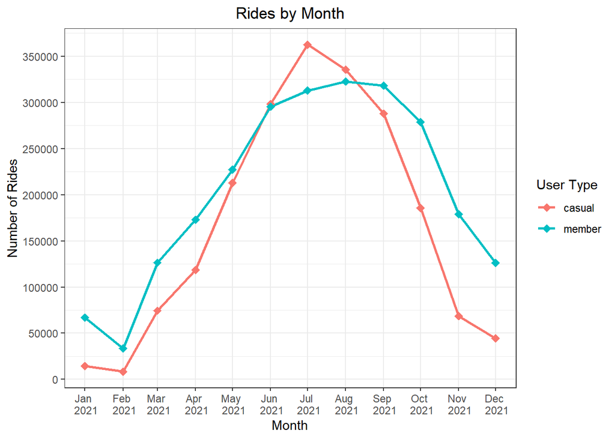

```r
df_summarized_by_time %>%
  group_by(user_type, month) %>%
  summarize(ride_count=sum(ride_count)) %>%
  ggplot(aes(x=as.Date(month, '%Y-%m-%d'), y=ride_count, group=user_type, color=user_type))+
  geom_line(size=1)+
  geom_point(aes(color=user_type), shape=18, size=3)+
  scale_y_continuous(breaks=scales::breaks_extended(n=10))+
  ggtitle('Rides by Month')+
  theme_bw()+
  theme(plot.title=element_text(hjust=0.5))+
  ylab('Number of Rides')+
  xlab('Month')+
  labs(color='User Type')+
  scale_x_date(date_labels='%b \n %Y', date_breaks='1 month', minor_breaks=NULL)
```

As expected, most rides happened in the warm months. Also the two user types have roughly the same amount of rides, but most rides in the winter season are from members.

In the next step, the change over the time of the day is analyzed.

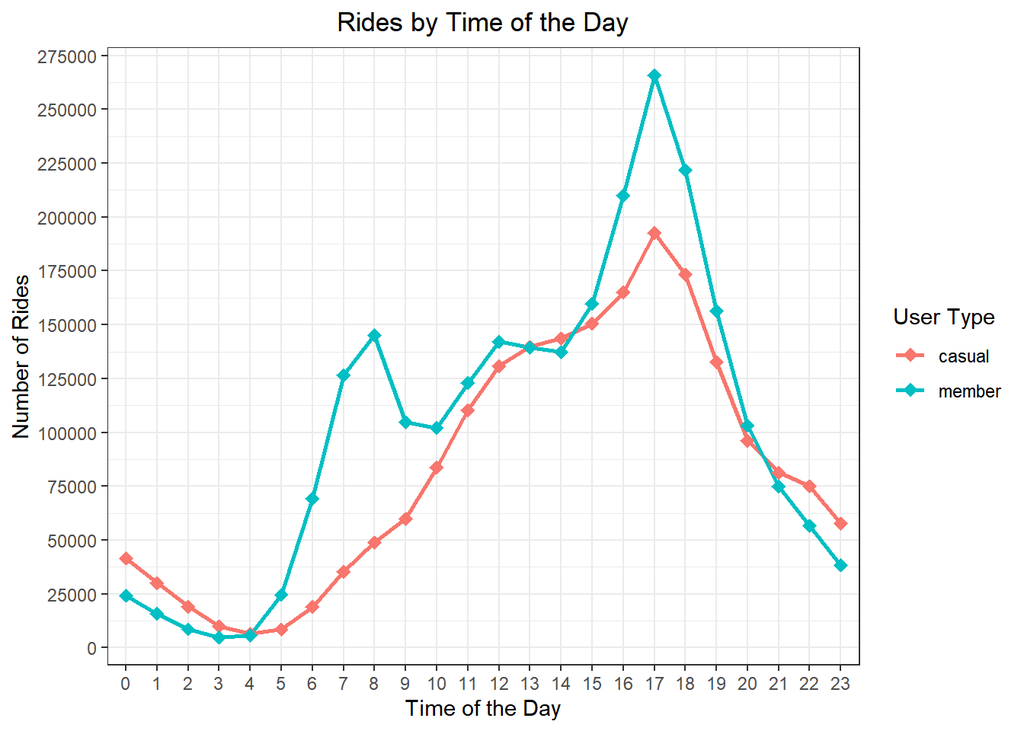

```r
df_summarized_by_time %>%
  group_by(user_type, hour) %>%
  summarize(ride_count=sum(ride_count)) %>%
  mutate(hour=factor(hour)) %>%
  ggplot(aes(x=hour, y=ride_count, group=user_type, color=user_type))+
  geom_line(size=1)+
  geom_point(aes(color=user_type), shape=18, size=3)+
  scale_y_continuous(breaks=scales::breaks_extended(n=10))+
  ggtitle('Rides by Time of the Day')+
  theme_bw()+
  theme(plot.title=element_text(hjust=0.5))+
  ylab('Number of Rides')+
  xlab('Time of the Day')+
  labs(color='User Type')
```

Here the expected low during night-time can be seen, but also strong differences between the user types: Most casual users are active in the afternoon. This is also true for members, but they’ve also peak during the morning. This pattern might occur because members use the bike for their way to and from work (or school, university, …), while causal users mainly use it to get to after-work activities.

Because the different user types might have used the bike on different hours on working days and weekends, the time of the day and day of the week are inspected together.

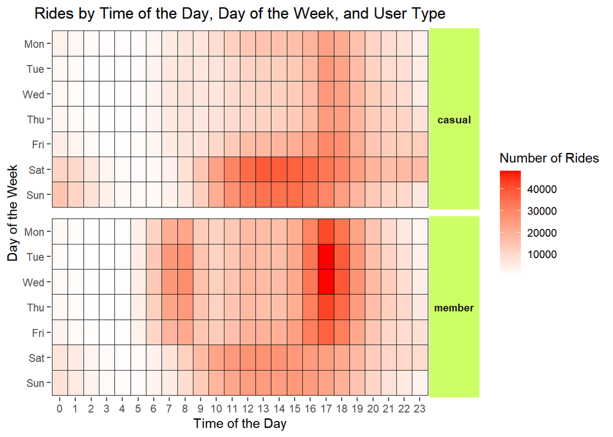

```r
df_summarized_by_time %>%
  group_by(user_type, day_of_week, hour) %>%
  summarize(ride_count=sum(ride_count)) %>%
  mutate(hour=factor(hour)) %>%
  ggplot(aes(x=hour, y=reorder(day_of_week, desc(day_of_week)), fill=ride_count))+
  geom_tile(color='black', size=0.1)+
  scale_fill_gradient(low='white', high='red')+
  theme(panel.grid=element_blank(),
        panel.background=element_blank(),
        strip.background=element_rect(fill='#ccff66'),
        strip.text.y=element_text(angle=0, face='bold'))+
  facet_grid(rows=vars(user_type))+
  ylab('Day of the Week')+
  xlab('Time of the Day')+
  labs(fill='Number of Rides')+
  ggtitle('Rides by Time of the Day, Day of the Week, and User Type')+
  theme(plot.title=element_text(hjust=0.5))
```

This graph indicates, that members used the bike mostly on working days in the morning and afternoon, but also during the weekends. This strongly supports, that members used the bikes to get to work and back home. Casual users mostly used the bike on afternoons during the week and all day at the weekends, probably to get to a after-work activity (hobby, friend) or a bike tour on the weekend.

As a next step it might be interesting to check, how long the trips took. But because the different available bike types may affect the trip duration it could be useful to analyze them first. To analyze both trip duration and bike type the data frame is summarized again, but this time by user type, bike type, and trip duration. Because the trip duration is continues, it was grouped into 10 minute long intervals.

```r
df_summarized_by_biketype_duration <- df %>%
  mutate(trip_duration_rounded=round((trip_duration+5), digits=-1)) %>%
  group_by(user_type, bike_type, trip_duration_rounded) %>%
  summarize(ride_count=n(), duration=sum(trip_duration))
```

To figure out, which bike types the two user types used, the percentage of rides for each bike type and user type was calculated and visualized.

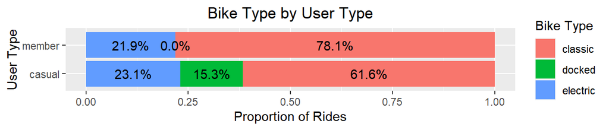

```r
df_summarized_by_biketype_duration %>%
  group_by(user_type, bike_type) %>%
  summarize(ride_count=sum(ride_count)) %>%
  mutate(proportion=ride_count/sum(ride_count)) %>%
  ggplot(aes(fill=bike_type, y=proportion, x=user_type), position='fill')+
  geom_col(position='fill')+
  ylab('Proportion of Rides')+
  xlab('User Type')+
  labs(fill='Bike Type')+
  geom_text(aes(label=scales::percent(proportion)), position=position_stack(0.5))+
  ggtitle('Bike Type by User Type')+
  theme(plot.title=element_text(hjust=0.5))+
  coord_flip()
```

To check the trip duration, the average trip duration for both user types is calculated, then the average trip duration by user type and bike type is visualized.

```r
df %>%
  group_by(user_type) %>%
  summarize(ride_count=n(), average_length=mean(trip_duration))
```

```
## # A tibble: 2 x 3
##   user_type ride_count average_length
##   <chr>          <int>          <dbl>
## 1 casual       2012052           28.7
## 2 member       2460567           13.6
```

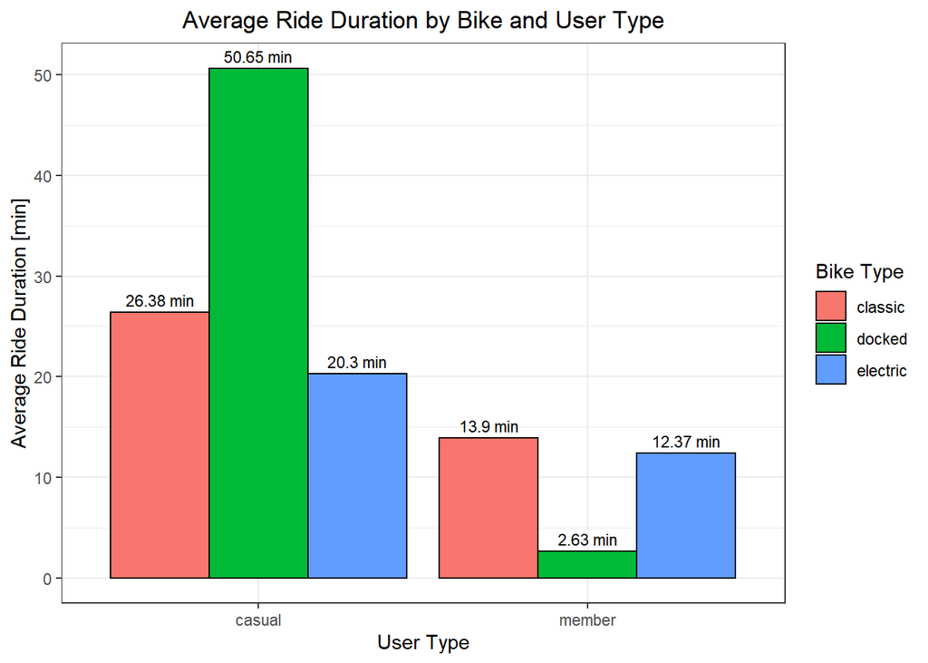

```r
df %>%
  group_by(user_type, bike_type) %>%
  summarize(ride_count=n(), average_ride_duration=mean(trip_duration)) %>%
  ggplot(aes(y=average_ride_duration, x=user_type, fill=bike_type))+
  geom_bar(stat='identity', color='black', position=position_dodge())+
  ylab('Average Ride Duration [min]')+
  xlab('User Type')+
  labs(fill='Bike Type')+
  ggtitle('Average Ride Duration by Bike and User Type')+
  theme_bw()+
  geom_text(size=3, aes(label=paste(round(average_ride_duration, 2), 'min')), position=position_dodge(0.9), vjust=-0.5)+
  theme(plot.title=element_text(hjust=0.5))
```

According to the trip duration, the trips of casual users took on average two times longer with a classic bike than the trips from members. That might be because most trips of members were to or from work, while most casuals trips are for free time activity.

To check the trip duration distribution, histograms were created based on the 10 minute bins from earlier. Because most of the trips are very short but a view took a whole day, the visualization is limited to three hours or less.

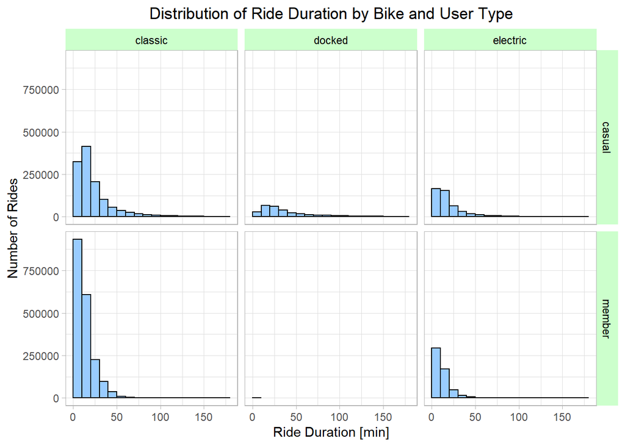

```r
df_summarized_by_biketype_duration %>%
  filter(trip_duration_rounded<=180) %>%
  ggplot(aes(x=trip_duration_rounded, y=ride_count))+
  geom_bar(stat='identity', width=10, color='black', fill='#99ccff' ,position=position_nudge(x=-5))+
  facet_grid(user_type ~ bike_type)+
  ylab('Number of Rides')+
  xlab('Ride Duration [min]')+
  ggtitle('Distribution of Ride Duration by Bike and User Type')+
  theme_light()+
  theme(strip.text=element_text(color='black'))+
  theme(strip.background=element_rect(fill='#ccffcc'))+
  theme(plot.title=element_text(hjust=0.5))
```

This shows no strong difference between the distributions. Member trips were shorter, like previously shown. Another small difference is, that casual users have a little bit more relative long trips, which could be bike tours.

#### Conclusion

The analysis provided some insights into the differences between the user types. However, there are still a lot of unknown elements. for example, it’s unknown, how much distance the trips covered. Even though the data provided the start and end coordinates of a trip, that’s not sufficient to calculate the distance driven. In the worst case, a person makes a long bike trip but returns the bike in the end to the start station, and therefore wouldn’t cover any ground. In addition, the coordinates only allow calculation of the distance as the crow flies, but not as a cyclist would actually drive. Also, because of the lack of knowledge about the city structure, geographic patters can’t be analysed. E.g. if the morning trips start in residential districts and end in industrial areas, or if people from certain districts use the bike more often than others. Another uncertainty are the individual users. Because the data didn’t contain a user id or something similar, it’s not possible to tell, how many users are there, or if they have some repeating pattern, e.g. every day at the same time the same trip. Such patterns would indicate a trip to work or something similar. This could be interesting for targeting specific groups, e.g. casual users which would benefit from a membership.

Based on this analysis I conclude, that there is not enough information about the users to launch a targeted advertisement campaign Instead, I recommend another analysis with the mentioned elements above, or a survey, were customers are asked, why they choose a member ship or why not, if they are aware of the benefits, and other similar questions.

In case a survey will be performed, the stations with the highest number of customers are listed below.

Start stations:

```r
df %>%
  mutate(member=ifelse(user_type=='member', 1, 0), casual=ifelse(user_type=='casual', 1, 0)) %>%
  group_by(start_station_name) %>%
  summarize(ride_count=n(), member=sum(member), casual=sum(casual)) %>%
  mutate(proportion_member=paste(round(member/ride_count*100, 2), '%')) %>%
  arrange(desc(ride_count), .group_by=TRUE) %>%
  filter(rank(desc(ride_count))<11)
```

```
## # A tibble: 10 x 5
##    start_station_name       ride_count member casual proportion_member
##    <chr>                         <int>  <dbl>  <dbl> <chr>
##  1 Streeter Dr & Grand Ave       78519  15347  63172 19.55 %
##  2 Michigan Ave & Oak St         41897  13764  28133 32.85 %
##  3 Wells St & Concord Ln         40673  22097  18576 54.33 %
##  4 Millennium Park               39533   7990  31543 20.21 %
##  5 Clark St & Elm St             38788  23402  15386 60.33 %
##  6 Wells St & Elm St             35224  19643  15581 55.77 %
##  7 Theater on the Lake           35105  14847  20258 42.29 %
##  8 Kingsbury St & Kinzie St      31319  21981   9338 70.18 %
##  9 Clark St & Lincoln Ave        31160  15136  16024 48.58 %
## 10 Clark St & Armitage Ave       30659  15524  15135 50.63 %
```

End stations:

```r
df %>%
  mutate(member=ifelse(user_type=='member', 1, 0), casual=ifelse(user_type=='casual', 1, 0)) %>%
  group_by(end_station_name) %>%
  summarize(ride_count=n(), member=sum(member), casual=sum(casual)) %>%
  mutate(proportion_member=paste(round(member/ride_count*100, 2), '%')) %>%
  arrange(desc(ride_count), .group_by=TRUE) %>%
  filter(rank(desc(ride_count))<11)
```

```
## # A tibble: 10 x 5
##    end_station_name         ride_count member casual proportion_member
##    <chr>                         <int>  <dbl>  <dbl> <chr>
##  1 Streeter Dr & Grand Ave       79985  13728  66257 17.16 %
##  2 Michigan Ave & Oak St         42613  12774  29839 29.98 %
##  3 Wells St & Concord Ln         41191  22854  18337 55.48 %
##  4 Millennium Park               40902   7762  33140 18.98 %
##  5 Clark St & Elm St             38190  23439  14751 61.37 %
##  6 Theater on the Lake           35607  13661  21946 38.37 %
##  7 Wells St & Elm St             35150  20272  14878 57.67 %
##  8 Wabash Ave & Grand Ave        31109  14835  16274 47.69 %
##  9 Clark St & Lincoln Ave        31028  14785  16243 47.65 %
## 10 Kingsbury St & Kinzie St      30705  21954   8751 71.5 %
```